# | Genomic selection, cross prediction and optimization

Marco Antonio Peixoto, Associate researcher[^1]

## Introduction

Genomic selection is a method that leverages both phenotype and genome data from historical individuals to develop a predictive model. In this way, from a training population we can calibrate a genomic model with markers and phenotypes. Hence, he can use those models to predict new individuals with only genotypic data.

In this vignette, we will give you a simple example on how to implement a genomic selection model and how to use it in Mate Allocation.To predict individual performance we will use **bWGR** package (Xavier 2019) and to guide cross performance and optimization we will use the **SimpleMating** package (Peixoto et al. 2025).

### Loading the packages

```r
#install.packages("bWGR")
library(bWGR)
#devtools::install_github("Resende-Lab/SimpleMating")
library(SimpleMating)
#install.packages("AGHmatrix")
library(AGHmatrix)
```

## Genomic selection model

### Loading the data

Step 1: Load the data from this repository

```r
# Download the data from here
url <- "https://raw.githubusercontent.com/marcopxt/marcopxt.github.io/master/talks_teach/Lectures/2025/UniArk/dataGS.RData"

dest <- "dataGS.RData"

download.file(url, destfile = dest, mode = "wb")
```

Step 2: Load the data from your computer (or if it is downloaded, you can only load it)

```r
# Load the dataset
load("dataGS.RData", verbose = TRUE)
```

```
## Loading objects:
##   Pheno
##   Geno
```

```r
# Phenotypes
head(Pheno)
```

```
##   Env Genotype   Trait1
## 1   1    26662 179.5075
## 2   1    30678 161.2597
## 3   1    30129 164.2701
## 4   1    28907 156.8915
## 5   1    30522 159.7874
## 6   1    26995 165.1254
```

```r
# Genotypes
table(Geno)
```

```
## Geno
##      0      1      2
## 790265 221892 487843
```

```r
Geno[1:10,1:10]
```

```
##       SNP1 SNP2 SNP3 SNP4 SNP5 SNP6 SNP7 SNP8 SNP9 SNP10
## 26662    2    0    2    0    2    2    0    0    0     0
## 30678    0    0    2    0    2    0    0    0    0     2
## 30129    2    0    2    0    2    2    0    0    0     0
## 28907    2    0    2    0    2    2    0    0    0     0
## 30522    2    0    2    0    2    2    0    0    0     0
## 26995    0    0    2    0    0    0    0    2    0     0
## 28468    0    0    2    0    2    0    0    2    0     0
## 31681    0    0    2    0    2    0    0    0    0     2
## 26661    1    0    2    0    2    1    0    1    0     0
## 30398    0    0    2    0    2    0    0    0    0     2
```

### Using genomic model to prediction individuals performance

For the prediction of individuals performance, we can use the bWGR function *wgr()* for solving it as a marker model. As an outcome, we going to see marker prediction and individuals prediction (the package does it internally).

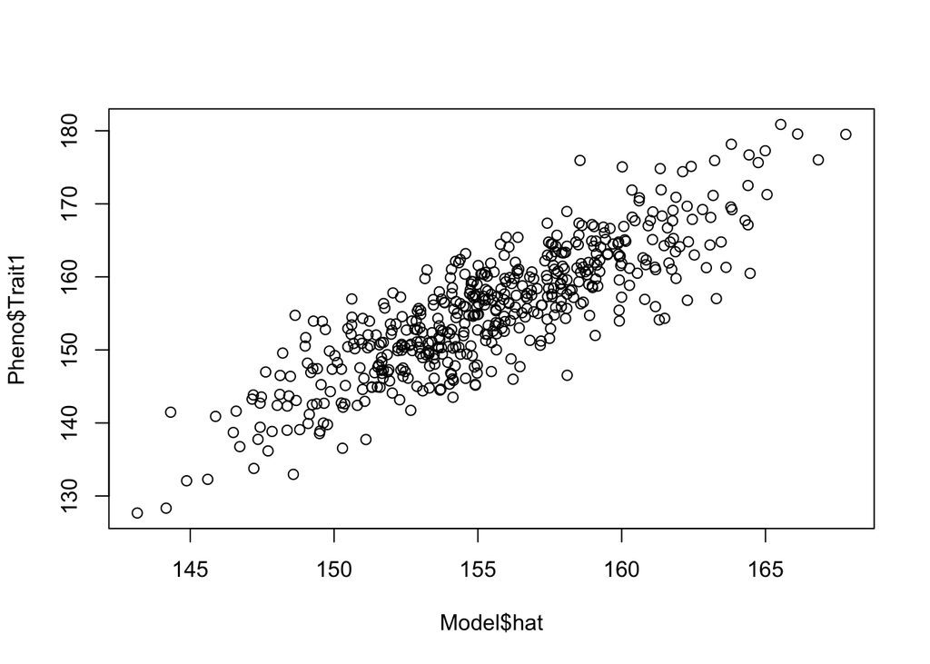

```r
# Model for markers
Model = wgr(y = Pheno$Trait1, # Phenotypes
          X = as.matrix(Geno)) # Genotypes

# Prediction to all individuals
plot(Model$hat, Pheno$Trait1)
```

```r
# Preparing the outcomes
parents <- data.frame(id = rownames(Geno),
                      blup = Model$hat)
```

## Using *SimpleMating* for cross prediction and optimization

In this part of the vignette, we will implement the SimpleMating algorithm to predict cross-performance and to generate a mating plan. There are two modules in SimpleMating: one to predict the cross performance of a group of individuals that are candidate to be parents, and a second module (*selectCrosses()* function) to optimize and generate the mating plan.

### Using the mid-parental value (capturing only additivity)

First, let’s begin by generating the crosses and estimating their performance based on additive values. The **mid-parental value** (MPV) represents the average of the two parents’ estimated breeding values.

$$MPV = \frac{ebv_{P_1} + ebv_{P_2}}{2}$$

where:

- $ebv_{P_1}$: estimated breeding value of Parent 1
- $ebv_{P_2}$: estimated breeding value of Parent 2

```r
# Creating a potential crosses
PlanCross <- SimpleMating::planCross(TargetPop = parents$id, MateDesign = 'half')
```

```
## Number of crosses generated: 124750
```

```r
# Relationship matrix
relMat = AGHmatrix::Gmatrix(Geno)
```

[output not shown]

```r
# Mid-parental value
MPV_pop <- SimpleMating::getMPV(MatePlan = PlanCross,
                                 Criterion = parents,
                                 K = relMat)
```

```
## 124750 possible crosses were predicted
```

```r
head(MPV_pop)
```

```
##   Parent1 Parent2        Y           K
## 1   26662   26632 167.3148  0.22279601
## 2   26662   30133 166.9552 -0.06087269
## 3   26662   26634 166.6616  0.20220529
## 4   26632   30133 166.4763  0.15235285
## 5   26662   26661 166.4238  0.93582357
## 6   26662   30546 166.3924 -0.09635004
```

### Optimization algorithm to generate the Mating Plan

```r
# Optimization
MatingPLan <- SimpleMating::selectCrosses(data = MPV_pop,
                            n.cross = 20,
                            max.cross = 4,
                            culling.pairwise.k = 0 )
# stats
MatingPLan[[1]]
```

```
##   culling.pairwise.k target.Y   target.K
## 1                  0 164.8998 -0.0965285
```

```r
# Mating Plan
MatingPLan[[2]]
```

```
##    Parent1 Parent2        Y           K
## 1    26662   30133 166.9552 -0.06087269
## 2    26662   30546 166.3924 -0.09635004
## 3    26662   30547 166.0928 -0.10064006
## 4    26632   30546 165.9135 -0.16503354
## 5    26632   30547 165.6139 -0.16022972
## 6    26661   30133 165.5852 -0.09060955
## 7    26670   30133 165.2910 -0.01256394
## 8    26672   30133 165.2722 -0.09474270
## 9    26661   30546 165.0224 -0.08516461
## 10   26632   27955 165.0073 -0.09661603
## 11   26632   30666 164.8243 -0.14568185
## 12   26661   30547 164.7229 -0.05194254
## 13   26661   30131 164.4443 -0.10410254
## 14   27930   26996 164.2792 -0.05900846
## 15   27930   26635 164.2707 -0.06474894
## 16   26672   30131 164.1313 -0.05935630
## 17   26672   27955 163.8032 -0.10727174
## 18   26670   30666 163.6391 -0.14804625
## 19   26672   30666 163.6203 -0.14724372
## 20   30398   26996 163.1140 -0.08034488
```

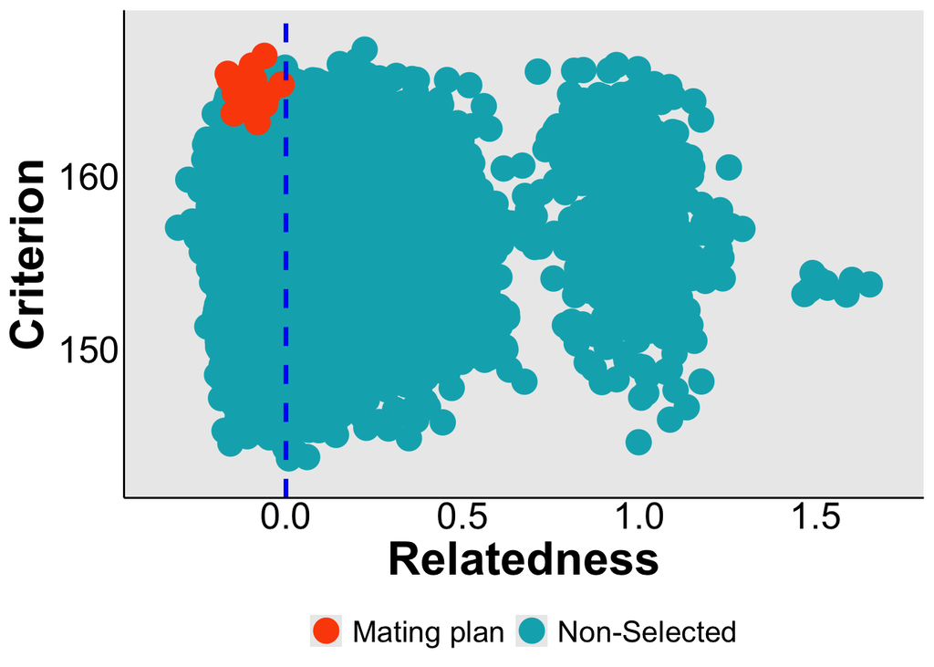

```r
# Plot
MatingPLan[[3]]
```

## References

Kinghorn, Brian. 1999. “19. Mate Selection for the Tactical Implementation of Breeding Programs.” *Proc Adv Anim Breed Genet* 13: 130–33.

Peixoto, Marco Antônio, Rodrigo Rampazo Amadeu, Leonardo Lopes Bhering, Luı́s Felipe V Ferrão, Patrı́cio R Munoz, and Márcio FR Resende Jr. 2025. “SimpleMating: R-Package for Prediction and Optimization of Breeding Crosses Using Genomic Selection.” *The Plant Genome* 18 (1): e20533.

Xavier, Alencar. 2019. “Efficient Estimation of Marker Effects in Plant Breeding.” *G3: Genes, Genomes, Genetics* 9 (11): 3855–66.

[^1]: University of Florida, deamorimpeixotom@ufl.edu